# Faraway_ch10

Harry Woo

2020 5 29

## Faraway Chapter 10 Variable Selection

### Problem 1

*Use the prostate data with lpsa as the response and the other variables as predictors. Implement the following variable selection methods to determine the “best” model:*

```r
library(faraway)
library(ggplot2)
library(GGally)
library(dplyr)
library(knitr)
library(MASS)
library(car)
library(tibble)
library(gridExtra)
library(leaps)
```

### Data loading and EDA

```r
data("prostate")
str(prostate)
```

```
## 'data.frame':    97 obs. of  9 variables:
##  $ lcavol : num  -0.58 -0.994 -0.511 -1.204 0.751 ...
##  $ lweight: num  2.77 3.32 2.69 3.28 3.43 ...
##  $ age    : int  50 58 74 58 62 50 64 58 47 63 ...
##  $ lbph   : num  -1.39 -1.39 -1.39 -1.39 -1.39 ...
##  $ svi    : int  0 0 0 0 0 0 0 0 0 0 ...
##  $ lcp    : num  -1.39 -1.39 -1.39 -1.39 -1.39 ...
##  $ gleason: int  6 6 7 6 6 6 6 6 6 6 ...
##  $ pgg45  : int  0 0 20 0 0 0 0 0 0 0 ...
##  $ lpsa   : num  -0.431 -0.163 -0.163 -0.163 0.372 ...
```

```r
summary(prostate)
```

```
##      lcavol           lweight           age             lbph
##  Min.   :-1.3471   Min.   :2.375   Min.   :41.00   Min.   :-1.3863
##  1st Qu.: 0.5128   1st Qu.:3.376   1st Qu.:60.00   1st Qu.:-1.3863
##  Median : 1.4469   Median :3.623   Median :65.00   Median : 0.3001
##  Mean   : 1.3500   Mean   :3.653   Mean   :63.87   Mean   : 0.1004
##  3rd Qu.: 2.1270   3rd Qu.:3.878   3rd Qu.:68.00   3rd Qu.: 1.5581
##  Max.   : 3.8210   Max.   :6.108   Max.   :79.00   Max.   : 2.3263
##       svi              lcp             gleason          pgg45
##  Min.   :0.0000   Min.   :-1.3863   Min.   :6.000   Min.   :  0.00
##  1st Qu.:0.0000   1st Qu.:-1.3863   1st Qu.:6.000   1st Qu.:  0.00
##  Median :0.0000   Median :-0.7985   Median :7.000   Median : 15.00
##  Mean   :0.2165   Mean   :-0.1794   Mean   :6.753   Mean   : 24.38
##  3rd Qu.:0.0000   3rd Qu.: 1.1786   3rd Qu.:7.000   3rd Qu.: 40.00
##  Max.   :1.0000   Max.   : 2.9042   Max.   :9.000   Max.   :100.00
##       lpsa
##  Min.   :-0.4308
##  1st Qu.: 1.7317
##  Median : 2.5915
##  Mean   : 2.4784
##  3rd Qu.: 3.0564
##  Max.   : 5.5829
```

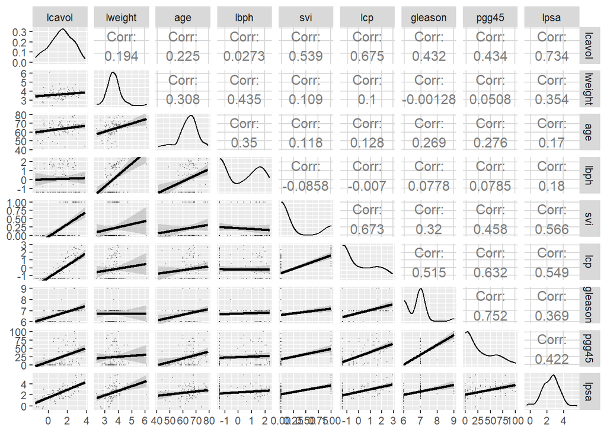

```r
ggpairs(prostate,
        lower = list(continuous = wrap("smooth", alpha = 0.3, size = 0.1)),
        diag = list(discrete="barDiag",
                    continuous = wrap("densityDiag", alpha = 0.5 )),
        upper = list(combo = wrap("box_no_facet", alpha = 0.5),
                            continuous = wrap("cor", size = 4,
                                              alignPercent = 0.8))) +
  theme(legend.position = "bottom")
```

#### Criterion-based procedures

#### (a) AIC

```r
pst_rs <- regsubsets(lpsa ~ ., data = prostate)
pst_rss <- summary(pst_rs)
pst_rss$which
```

```
##   (Intercept) lcavol lweight   age  lbph   svi   lcp gleason pgg45
## 1        TRUE   TRUE   FALSE FALSE FALSE FALSE FALSE   FALSE FALSE
## 2        TRUE   TRUE    TRUE FALSE FALSE FALSE FALSE   FALSE FALSE
## 3        TRUE   TRUE    TRUE FALSE FALSE  TRUE FALSE   FALSE FALSE
## 4        TRUE   TRUE    TRUE FALSE  TRUE  TRUE FALSE   FALSE FALSE
## 5        TRUE   TRUE    TRUE  TRUE  TRUE  TRUE FALSE   FALSE FALSE
## 6        TRUE   TRUE    TRUE  TRUE  TRUE  TRUE FALSE   FALSE  TRUE
## 7        TRUE   TRUE    TRUE  TRUE  TRUE  TRUE  TRUE   FALSE  TRUE
## 8        TRUE   TRUE    TRUE  TRUE  TRUE  TRUE  TRUE    TRUE  TRUE
```

`leaps` 패키지의 `regsubsets` 문을 활용하여 설명변수들의 모든 가능한 조합을 검토하여 주어진 모델 크기에서 최적의 RSS를 갖는 변수들을 찾아내어, 이를 `pst_rss`로 저장하였다.

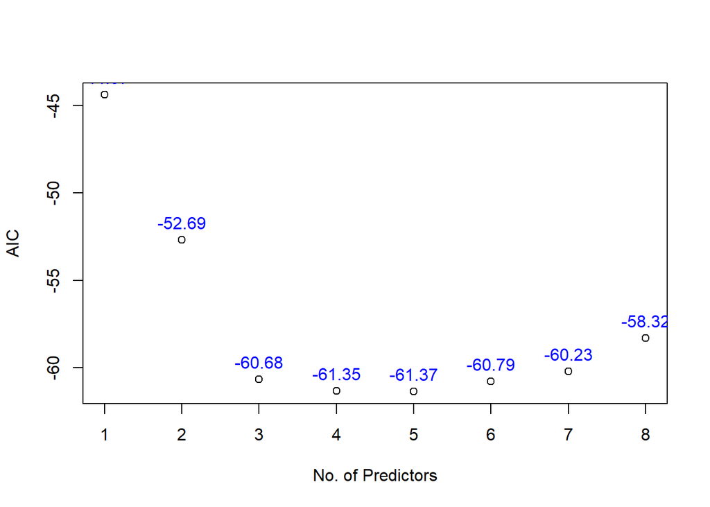

```r
#linear regression 에서 -2 max log-likelihood는 nlog(RSS/n) + 2p(penalty term)

pst_n <- nrow(prostate)
pst_AIC <- pst_n * log(pst_rss$rss / pst_n) + (2:9) * 2
plot(pst_AIC ~ I(1:8), ylab = "AIC", xlab = "No. of Predictors")
text(1:8, pst_AIC + 1, labels = round(pst_AIC, 2), col = "blue", cex= 1)
```

```r
which.min(pst_AIC)
```

```
## [1] 5
```

Akaike Information Crieteria(AIC)를 변수선택 기준으로 활용할 때는 여러 모형 중 AIC가 가장 낮은 모형이 최적 모형으로 선택된다. `lpsa_rss` 자료를 기준으로, 설명변수의 조합에 따른 AIC 값을 계산하여 표로 나타낸 결과, 5개의 변수(`lcavol`, `lweight`, `age`, `lbph`, `svi`)를 사용했을 때 AIC 값이 최저임을 확인할 수 있다.

#### (b) Adjusted R2

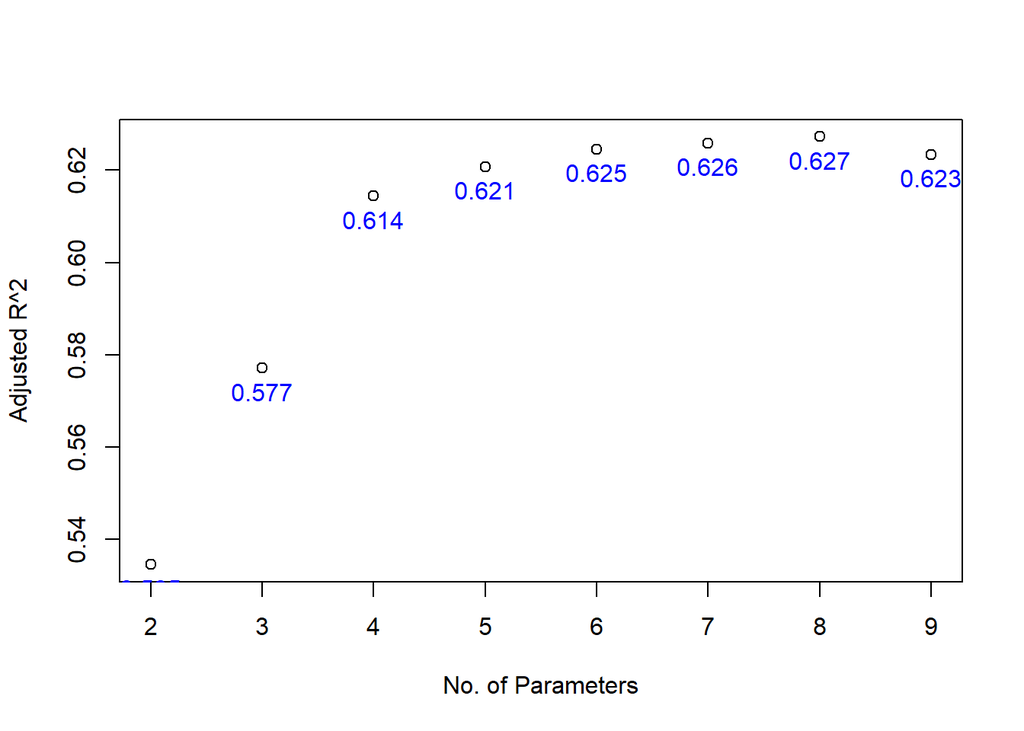

```r
plot(2:9, pst_rss$adjr2, xlab = "No. of Parameters", ylab = "Adjusted R^2")
text(2:9, pst_rss$adjr2 - 0.005, labels = round(pst_rss$adjr2, 3), col = "blue", cex= 1)
```

```r
which.max(pst_rss$adjr2) #결과 7 -> 변수 7개 조합을 의미
```

```
## [1] 7
```

#### (c) Mallows Cp

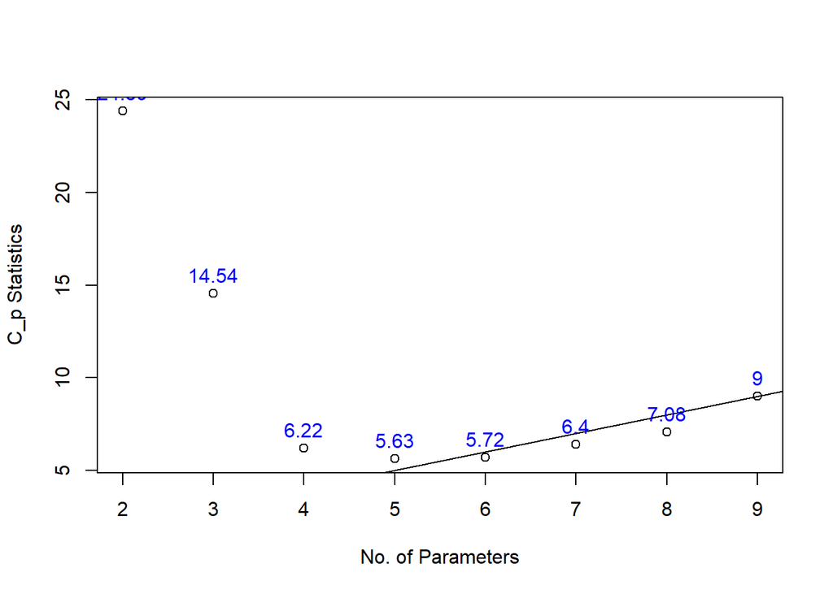

```r
# C_p = SSE_p / MSE + 2p - n

plot(2:9, pst_rss$cp, xlab = "No. of Parameters", ylab = "C_p Statistics")
abline(0, 1)
text(2:9, pst_rss$cp + 1, labels = round(pst_rss$cp, 2), col = "blue", cex= 1)
```

```r
pst_rss$cp
```

```
## [1] 24.394559 14.541475  6.216935  5.626422  5.715016  6.401965  7.082184
## [8]  9.000000
```

```r
which.min(pst_rss$cp)
```

```
## [1] 4
```

모든 변수를 포함했을 때의 full model을 기준으로, p개의 설명변수를 포함하는 모형의 fit을 검토하기 위해 MSE의 n개의 합을 이용하는 C_p 통계량을 활용할 수 있다. 가급적 낮은 C_p 값이 더 선호되며 C_p가 parameter의 개수 p에 근사한 모델이 일반적으로 선택된다.

Mallows C_p를 통해 검토한 결과, 변수 4개 모델과 변수 5개 모델 사이의 competition이 관찰된다. C_p가 p 이상인 모델에서 변수 4개 모델(`lcavol`, `lweight`, `lbph`, `svi`)이 가장 낮은 C_p 값을 가지며, `age`가 추가된 변수 5개 모델(`lcavol`, `lweight`, `age`, `lbph`, `svi`)은 C_p가 p+1 보다 작고 거의 p에 근사하다는 점에서 두 모델 모두 최적모델로 고려할 수 있을 것으로 판단된다.

#### (d) Forward selection method

```r
#step 문을 활용한 전진 선택법

pst_lm_null <- lm(lpsa ~ 1, data = prostate) #
pst_lm_full <- lm(lpsa ~ ., data = prostate)

step(pst_lm_null, scope = list(lower = pst_lm_null, upper = pst_lm_full),
     data = prostate, direction = "forward")
```

```
## Start:  AIC=28.84
## lpsa ~ 1
##
##           Df Sum of Sq     RSS     AIC
## + lcavol   1    69.003  58.915 -44.366
## + svi      1    41.011  86.907  -6.658
## + lcp      1    38.528  89.389  -3.926
## + pgg45    1    22.814 105.103  11.783
## + gleason  1    17.416 110.501  16.641
## + lweight  1    16.041 111.876  17.840
## + lbph     1     4.136 123.782  27.650
## + age      1     3.679 124.238  28.007
## <none>                 127.918  28.837
##
## Step:  AIC=-44.37
## lpsa ~ lcavol
##
##           Df Sum of Sq    RSS     AIC
## + lweight  1    5.9485 52.966 -52.690
## + svi      1    5.2375 53.677 -51.397
## + lbph     1    3.2658 55.649 -47.898
## + pgg45    1    1.6980 57.217 -45.203
## <none>                 58.915 -44.366
## + lcp      1    0.6562 58.259 -43.453
## + gleason  1    0.4156 58.499 -43.053
## + age      1    0.0025 58.912 -42.370
##
## Step:  AIC=-52.69
## lpsa ~ lcavol + lweight
##
##           Df Sum of Sq    RSS     AIC
## + svi      1    5.1814 47.785 -60.676
## + pgg45    1    1.9489 51.017 -54.327
## <none>                 52.966 -52.690
## + lcp      1    0.8371 52.129 -52.236
## + gleason  1    0.7810 52.185 -52.131
## + lbph     1    0.6751 52.291 -51.935
## + age      1    0.4200 52.546 -51.463
##
## Step:  AIC=-60.68
```

[output cut: 13 more lines]

```
##           Df Sum of Sq    RSS     AIC
## + age      1   0.95924 45.526 -61.374
## <none>                 46.485 -61.352
## + pgg45    1   0.35332 46.131 -60.092
## + gleason  1   0.21256 46.272 -59.796
## + lcp      1   0.10230 46.383 -59.565
##
## Step:  AIC=-61.37
## lpsa ~ lcavol + lweight + svi + lbph + age
##
##           Df Sum of Sq    RSS     AIC
## <none>                 45.526 -61.374
## + pgg45    1   0.65896 44.867 -60.789
## + gleason  1   0.45601 45.070 -60.351
## + lcp      1   0.12927 45.396 -59.650
```

```
##
## Call:
## lm(formula = lpsa ~ lcavol + lweight + svi + lbph + age, data = prostate)
##
## Coefficients:
## (Intercept)       lcavol      lweight          svi         lbph          age
##     0.95100      0.56561      0.42369      0.72095      0.11184     -0.01489
```

```r
summary(lm(formula = lpsa ~ lcavol + lweight + svi + lbph + age, data = prostate))
```

```
##
## Call:
## lm(formula = lpsa ~ lcavol + lweight + svi + lbph + age, data = prostate)
##
## Residuals:
##      Min       1Q   Median       3Q      Max
## -1.83505 -0.39396  0.00414  0.46336  1.57888
##
## Coefficients:
##             Estimate Std. Error t value Pr(>|t|)
## (Intercept)  0.95100    0.83175   1.143 0.255882
## lcavol       0.56561    0.07459   7.583 2.77e-11 ***
## lweight      0.42369    0.16687   2.539 0.012814 *
## svi          0.72095    0.20902   3.449 0.000854 ***
## lbph         0.11184    0.05805   1.927 0.057160 .
## age         -0.01489    0.01075  -1.385 0.169528
## ---
## Signif. codes:  0 '***' 0.001 '**' 0.01 '*' 0.05 '.' 0.1 ' ' 1
##
## Residual standard error: 0.7073 on 91 degrees of freedom
## Multiple R-squared:  0.6441, Adjusted R-squared:  0.6245
## F-statistic: 32.94 on 5 and 91 DF,  p-value: < 2.2e-16
```

`step` 문을 활용한 전진선택법을 실시하였다. 절편만을 포함한 모형 `pst_lm_null`에서 시작하여, 설명변수를 하나씩 추가하였을 때 AIC 값이 가장 작은 설명변수를 선택하고, 검정결과가 유의할 때까지 설명변수를 추가한 결과, 5개의 변수(`lcavol`, `lweight`, `svi`, `lbph`, `age`)를 포함하는 모형이 최종 모델로 선택되었다.

#### (e) Stepwise Selection method

```r
step(pst_lm_null, scope = list(upper = pst_lm_full), data = prostate,
     direction = "both")
```

```
## Start:  AIC=28.84
## lpsa ~ 1
##
##           Df Sum of Sq     RSS     AIC
## + lcavol   1    69.003  58.915 -44.366
## + svi      1    41.011  86.907  -6.658
## + lcp      1    38.528  89.389  -3.926
## + pgg45    1    22.814 105.103  11.783
## + gleason  1    17.416 110.501  16.641
## + lweight  1    16.041 111.876  17.840
## + lbph     1     4.136 123.782  27.650
## + age      1     3.679 124.238  28.007
## <none>                 127.918  28.837
##
## Step:  AIC=-44.37
## lpsa ~ lcavol
##
##           Df Sum of Sq     RSS     AIC
## + lweight  1     5.949  52.966 -52.690
## + svi      1     5.237  53.677 -51.397
## + lbph     1     3.266  55.649 -47.898
## + pgg45    1     1.698  57.217 -45.203
## <none>                  58.915 -44.366
## + lcp      1     0.656  58.259 -43.453
## + gleason  1     0.416  58.499 -43.053
## + age      1     0.003  58.912 -42.370
## - lcavol   1    69.003 127.918  28.837
##
## Step:  AIC=-52.69
## lpsa ~ lcavol + lweight
##
##           Df Sum of Sq     RSS     AIC
## + svi      1     5.181  47.785 -60.676
## + pgg45    1     1.949  51.017 -54.327
## <none>                  52.966 -52.690
## + lcp      1     0.837  52.129 -52.236
## + gleason  1     0.781  52.185 -52.131
## + lbph     1     0.675  52.291 -51.935
## + age      1     0.420  52.546 -51.463
## - lweight  1     5.949  58.915 -44.366
```

[output cut: 28 more lines]

```
## - lcavol   1   27.8298 74.315 -17.841
##
## Step:  AIC=-61.37
## lpsa ~ lcavol + lweight + svi + lbph + age
##
##           Df Sum of Sq    RSS     AIC
## <none>                 45.526 -61.374
## - age      1    0.9592 46.485 -61.352
## + pgg45    1    0.6590 44.867 -60.789
## + gleason  1    0.4560 45.070 -60.351
## + lcp      1    0.1293 45.396 -59.650
## - lbph     1    1.8568 47.382 -59.497
## - lweight  1    3.2251 48.751 -56.735
## - svi      1    5.9517 51.477 -51.456
## - lcavol   1   28.7665 74.292 -15.871
```

```
##
## Call:
## lm(formula = lpsa ~ lcavol + lweight + svi + lbph + age, data = prostate)
##
## Coefficients:
## (Intercept)       lcavol      lweight          svi         lbph          age
##     0.95100      0.56561      0.42369      0.72095      0.11184     -0.01489
```

`step` 문을 활용한 단계별(stepwise) 선택법을 실시하였다. 전진선택법에서와 같이 절편만을 포함한 모형 `pst_lm_null`에서 시작하여, 설명변수를 하나씩 추가하였을 때 AIC 값이 가장 작은 설명변수를 선택하되, 검정결과가 유의하지 않을 경우 해당 설명변수를 제거하고 다시 설명변수의 추가를 검토하는 과정을 반복한 결과, 5개의 변수(`lcavol`, `lweight`, `svi`, `lbph`, `age`)를 포함하는 모형이 최종 모델로 선택되었다.

### Problem 2

*Using the trees data, fit a model with log (Volume) as the response and a second-order polynomial (including the interaction term) in Girth and Height. Determine whether the model may be reasonably simplified.*

### Data loading and EDA

```r
data("trees")
str(trees)
```

```
## 'data.frame':    31 obs. of  3 variables:
##  $ Girth : num  8.3 8.6 8.8 10.5 10.7 10.8 11 11 11.1 11.2 ...
##  $ Height: num  70 65 63 72 81 83 66 75 80 75 ...
##  $ Volume: num  10.3 10.3 10.2 16.4 18.8 19.7 15.6 18.2 22.6 19.9 ...
```

```r
summary(trees)
```

```
##      Girth           Height       Volume
##  Min.   : 8.30   Min.   :63   Min.   :10.20
##  1st Qu.:11.05   1st Qu.:72   1st Qu.:19.40
##  Median :12.90   Median :76   Median :24.20
##  Mean   :13.25   Mean   :76   Mean   :30.17
##  3rd Qu.:15.25   3rd Qu.:80   3rd Qu.:37.30
##  Max.   :20.60   Max.   :87   Max.   :77.00
```

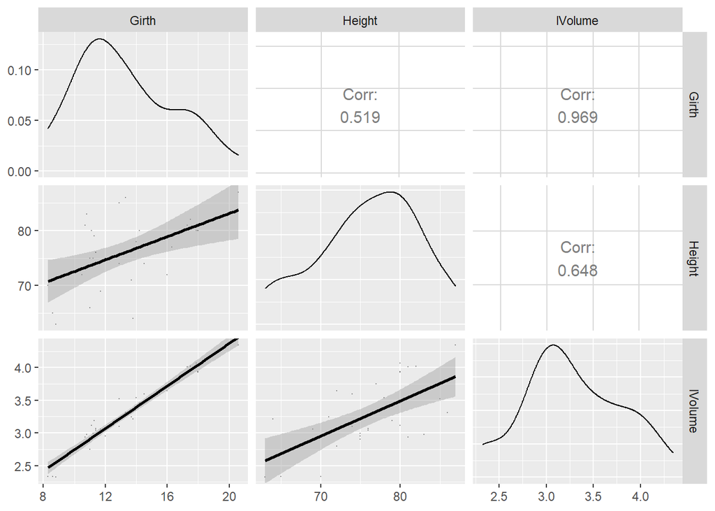

```r
trees %>% mutate(lVolume = log(Volume)) %>% dplyr::select(Girth, Height, lVolume) %>%
  ggpairs(.,
        lower = list(continuous = wrap("smooth", alpha = 0.3, size = 0.1)),
        diag = list(discrete="barDiag",
                    continuous = wrap("densityDiag", alpha = 0.5 )),
        upper = list(combo = wrap("box_no_facet", alpha = 0.5),
                            continuous = wrap("cor", size = 4,
                                              alignPercent = 0.8))) +
  theme(legend.position = "bottom")
```

```r
trees_lm <- lm(log(Volume) ~ Girth + Height + I(Girth^2) + I(Height^2) + Girth:Height, data=trees)
summary(trees_lm)
```

```
##
## Call:
## lm(formula = log(Volume) ~ Girth + Height + I(Girth^2) + I(Height^2) +
##     Girth:Height, data = trees)
##
## Residuals:
##       Min        1Q    Median        3Q       Max
## -0.159718 -0.041905 -0.003371  0.055167  0.133780
##
## Coefficients:
##                Estimate Std. Error t value Pr(>|t|)
## (Intercept)  -1.9660208  2.0066922  -0.980  0.33660
## Girth         0.2808126  0.0786856   3.569  0.00149 **
## Height        0.0484196  0.0567321   0.853  0.40150
## I(Girth^2)   -0.0042410  0.0032183  -1.318  0.19953
## I(Height^2)  -0.0002022  0.0004186  -0.483  0.63326
## Girth:Height -0.0001975  0.0018089  -0.109  0.91395
## ---
## Signif. codes:  0 '***' 0.001 '**' 0.01 '*' 0.05 '.' 0.1 ' ' 1
##
## Residual standard error: 0.08469 on 25 degrees of freedom
## Multiple R-squared:  0.9784, Adjusted R-squared:  0.9741
## F-statistic: 226.7 on 5 and 25 DF,  p-value: < 2.2e-16
```

문제에서 주어진 내용대로 `log(Volume)`을 종속변수로, `Girth`와 `Height` 및 2차식, 교호작용까지 고려한 회귀모형을 `trees_lm`으로 적합하였다. 적합 결과, 결정계수는 0.9784로 매우 높으나 설명변수 중 `Girth` 하나만이 유의수준 0.05에서 유의한 것으로 나타나 좋은 모델이라고 할 수 없다.

이에, 후진제거법을 활용하여 모델을 개선, 단순화해보았다.

```r
step(trees_lm, data = trees, direction = "backward")
```

```
## Start:  AIC=-147.73
## log(Volume) ~ Girth + Height + I(Girth^2) + I(Height^2) + Girth:Height
##
##                Df Sum of Sq     RSS     AIC
## - Girth:Height  1 0.0000855 0.17941 -149.72
## - I(Height^2)   1 0.0016737 0.18100 -149.44
## <none>                      0.17932 -147.73
## - I(Girth^2)    1 0.0124560 0.19178 -147.65
##
## Step:  AIC=-149.71
## log(Volume) ~ Girth + Height + I(Girth^2) + I(Height^2)
##
##               Df Sum of Sq     RSS     AIC
## - I(Height^2)  1  0.002487 0.18189 -151.29
## - Height       1  0.005377 0.18478 -150.80
## <none>                     0.17941 -149.72
## - I(Girth^2)   1  0.055232 0.23464 -143.39
## - Girth        1  0.248603 0.42801 -124.76
##
## Step:  AIC=-151.29
## log(Volume) ~ Girth + Height + I(Girth^2)
##
##              Df Sum of Sq     RSS     AIC
## <none>                    0.18189 -151.29
## - I(Girth^2)  1   0.08025 0.26214 -141.96
## - Height      1   0.21815 0.40004 -128.85
## - Girth       1   0.32692 0.50881 -121.40
```

```
##
## Call:
## lm(formula = log(Volume) ~ Girth + Height + I(Girth^2), data = trees)
##
## Coefficients:
## (Intercept)        Girth       Height   I(Girth^2)
##   -0.783931     0.285333     0.015701    -0.004954
```

```r
summary(lm(formula = log(Volume) ~ Girth + Height + I(Girth^2), data = trees))
```

```
##
## Call:
## lm(formula = log(Volume) ~ Girth + Height + I(Girth^2), data = trees)
##
## Residuals:
##       Min        1Q    Median        3Q       Max
## -0.174348 -0.043284 -0.000147  0.059198  0.138282
##
## Coefficients:
##              Estimate Std. Error t value Pr(>|t|)
## (Intercept) -0.783931   0.315182  -2.487  0.01935 *
## Girth        0.285333   0.040960   6.966 1.74e-07 ***
## Height       0.015701   0.002759   5.690 4.80e-06 ***
## I(Girth^2)  -0.004954   0.001435  -3.451  0.00185 **
## ---
## Signif. codes:  0 '***' 0.001 '**' 0.01 '*' 0.05 '.' 0.1 ' ' 1
##
## Residual standard error: 0.08208 on 27 degrees of freedom
## Multiple R-squared:  0.9781, Adjusted R-squared:  0.9757
## F-statistic: 402.1 on 3 and 27 DF,  p-value: < 2.2e-16
```

후진제거법을 통해 AIC 값을 최소화한 결과, `Height^2` 및 두 설명변수의 교호작용 항이 제거되었다.

```r
trees_final <- lm(formula = log(Volume) ~ Girth + Height + I(Girth^2), data = trees)
summary(trees_final)
```

```
##
## Call:
## lm(formula = log(Volume) ~ Girth + Height + I(Girth^2), data = trees)
##
## Residuals:
##       Min        1Q    Median        3Q       Max
## -0.174348 -0.043284 -0.000147  0.059198  0.138282
##
## Coefficients:
##              Estimate Std. Error t value Pr(>|t|)
## (Intercept) -0.783931   0.315182  -2.487  0.01935 *
## Girth        0.285333   0.040960   6.966 1.74e-07 ***
## Height       0.015701   0.002759   5.690 4.80e-06 ***
## I(Girth^2)  -0.004954   0.001435  -3.451  0.00185 **
## ---
## Signif. codes:  0 '***' 0.001 '**' 0.01 '*' 0.05 '.' 0.1 ' ' 1
##
## Residual standard error: 0.08208 on 27 degrees of freedom
## Multiple R-squared:  0.9781, Adjusted R-squared:  0.9757
## F-statistic: 402.1 on 3 and 27 DF,  p-value: < 2.2e-16
```

```r
anova(trees_lm, trees_final)
```

```
## Analysis of Variance Table
##
## Model 1: log(Volume) ~ Girth + Height + I(Girth^2) + I(Height^2) + Girth:Height
## Model 2: log(Volume) ~ Girth + Height + I(Girth^2)
##   Res.Df     RSS Df  Sum of Sq      F Pr(>F)
## 1     25 0.17932
## 2     27 0.18189 -2 -0.0025722 0.1793 0.8369
```

최종 모델 `trees_final`의 summary 확인 결과, 3개 변수(`Girth`, `Height`, `Girth^2`)가 모두 유의하며 결정계수 또한 큰 차이가 없는 것으로 나타났다. anova 결과에서도 p-value가 0.05 이상으로 귀무가설을 기각할 수 없는 바, 최종 모델 `trees_final`이 기존 모형보다 더 개선, 단순화되었음을 확인할 수 있다.